# Trends in Chlorophyll

```r
mod
```

```
Family: gaussian
Link function: identity

Formula:
value ~ s(cont_year, k = 220)

Estimated degrees of freedom:
72.6  total = 73.59

GCV score: 0.08401263
```

Now to assess fit of the model by using `anlz_smooth()` to assess individual smoother functions and `anlz_fit()` for overall fit.

```r
anlz_smooth(mod)
```

```
      smoother      edf   Ref.df        F p.value
1 s(cont_year) 72.58958 90.10996 3.823626       0
```

from the help: *“the estimated degrees of freedom (`edf`), the reference degrees of freedom (`Ref.df`), the test statistic (`F`), and significance of the component (`p-value`). The significance of the component is in part based on the difference between `edf` and `Ref.df`.”*

```r
anlz_fit(mod)
```

```
            AIC        GCV        R2
GCV.Cp 55.91348 0.08401263 0.5820661
```

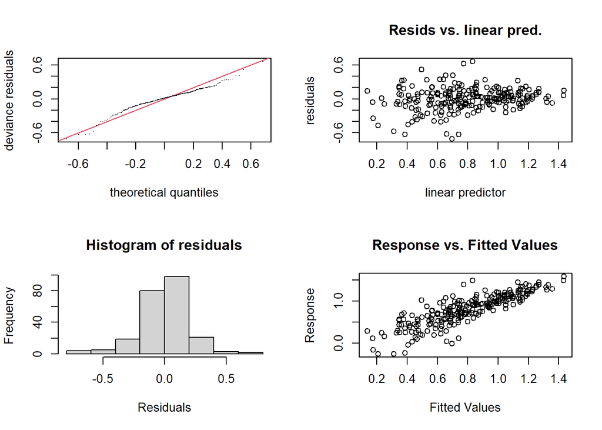

```
Method: GCV   Optimizer: magic
Smoothing parameter selection converged after 4 iterations.
The RMS GCV score gradient at convergence was 1.279252e-06 .
The Hessian was positive definite.
Model rank =  220 / 220

Basis dimension (k) checking results. Low p-value (k-index<1) may
indicate that k is too low, especially if edf is close to k'.

                k'   edf k-index p-value
s(cont_year) 219.0  72.6    1.39       1
```

```r
par(mfrow=c(2,2))
gam.check(mod)
```

Estimate results by day of year

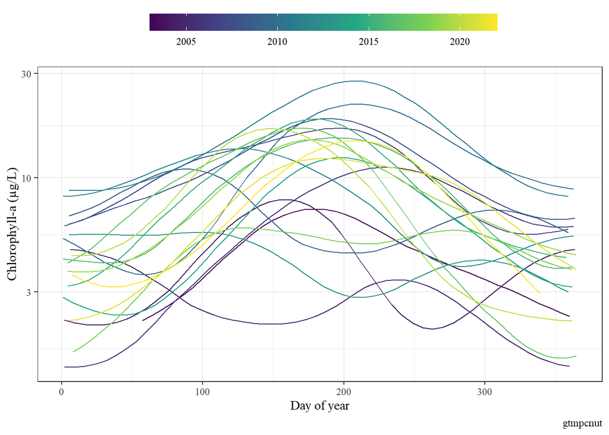

```r
ylab <- "Chlorophyll-a (\U00B5g/L)"
show_prddoy(mod, ylab = ylab) + labs(caption = "gtmpcnut")
```

Predictions for the model across the entire time series. Points are the observed data and the lines are the predicted.

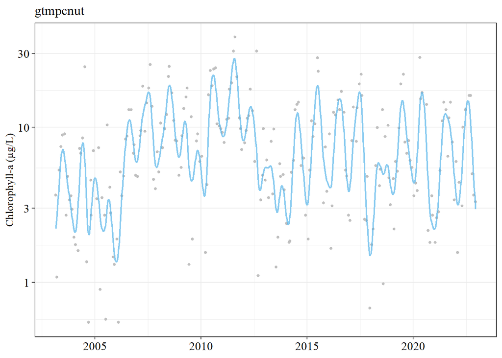

```r
show_prdseries_mod(mod, ylab = "Chlorophyll-a (\U00B5g/L)", site = "gtmpcnut")
```

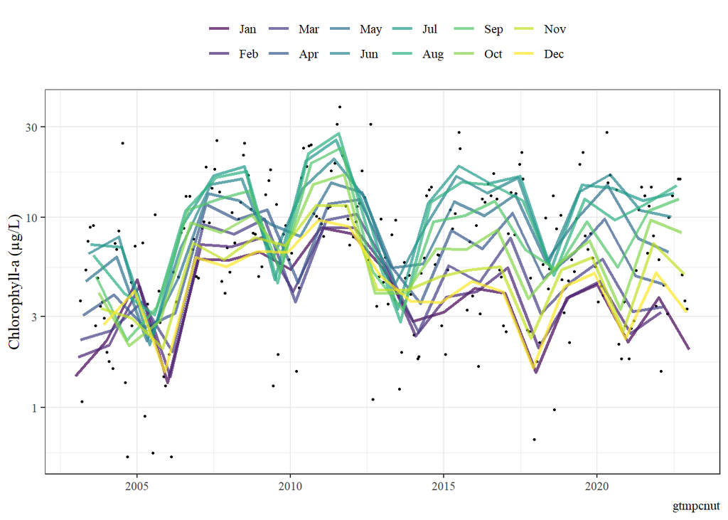

```r
show_prdseason(mod, ylab = ylab) + labs(caption = "gtmpcnut")
```

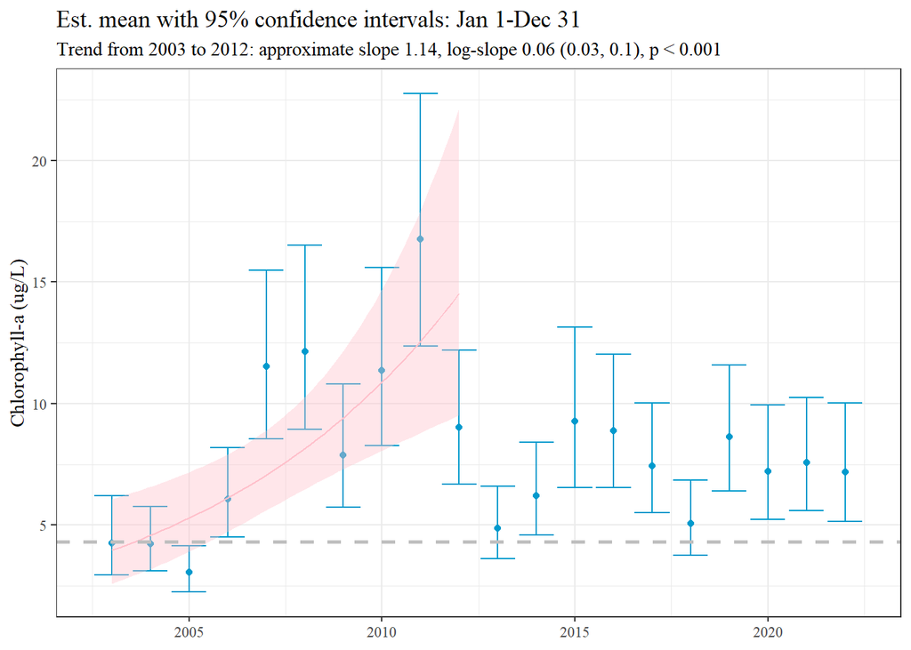

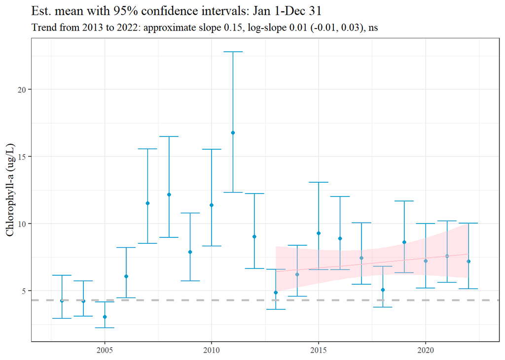

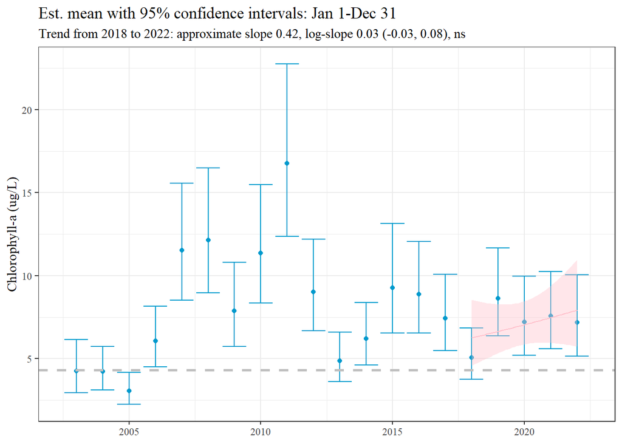

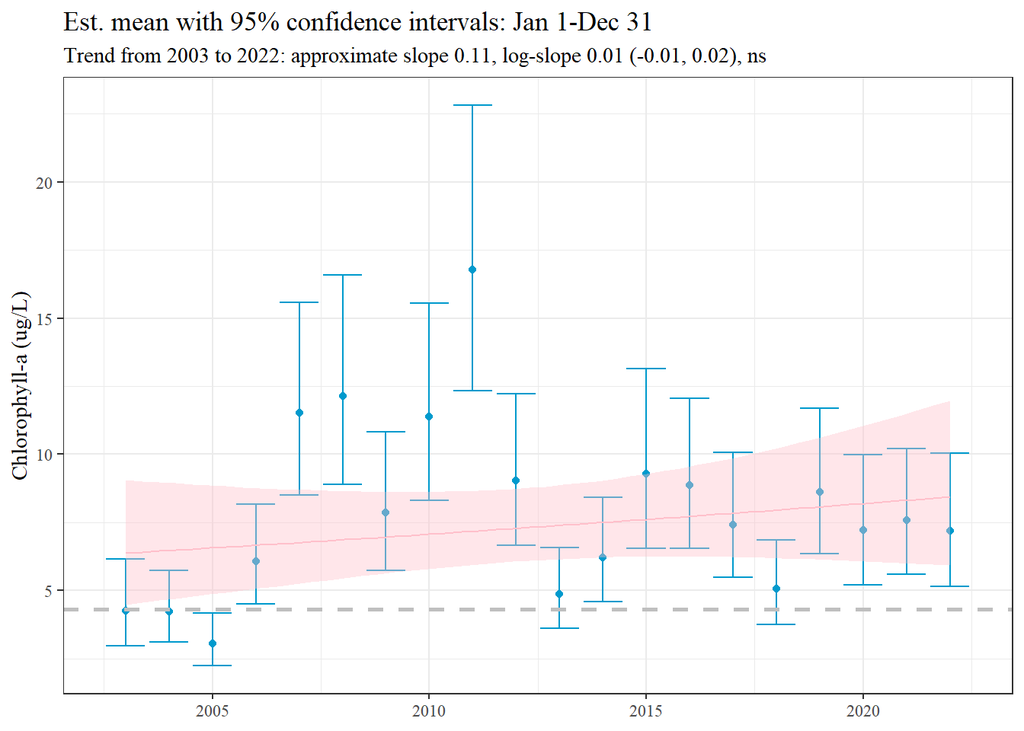

## Variability

Using methods from (**cloern2010?**), variability and patterns in the monthly chlorophyll *a* data were further extracted by decomposing the timeseries at each station using Equation 4 into an annual effect, mean seasonal pattern, and residual “events”.

**Equation 4 from (**cloern2010?**):**

$$c_{ij}=Cy_im_j\epsilon_{ij}$$
Where $c_{ij}$ is chlorophyll concentration in year $i$($i=1,...,N$) and month $j$($j=1,...12$); *C* is the long-term mean of the series; $y_i$ is the annual effect in the *i*th year; $m_j$ is the seasonal (monthly) effect in the *j*th month; and $\epsilon_{ij}$ is the residual.

- If $y_i$ >1, indicates a year with above-average mean Chl-*a*.
- If $m_j$ >1, indicates a mean monthly Chl-*a* greater than the annual mean.
- If $\epsilon_{ij}$ >1, indicates an observation greater than the expected value for that month and year.

::: {.panel-tabset}

### Pine Island

Using the decomposition function from (**cloern2010?**), summary information

```r
summary(decomp.mult(ts(as.data.frame(chla_dat %>%
                                                      filter(station == "gtmpinut") %>%
                                                      select(date, value) %>%
                                                      bind_rows(mis) %>%
                                                      arrange(date) %>%
                                                      select(value)
                                                     ),
                                     start = c(2003, 1),
                                     end = c(2022, 12),
                                     frequency = 12)))
```

```
    original        grandmean        interann          season
 Min.   : 1.100   Min.   :5.537   Min.   :0.6426   Min.   :0.6759
 1st Qu.: 3.325   1st Qu.:5.537   1st Qu.:0.8509   1st Qu.:0.7191
 Median : 4.750   Median :5.537   Median :0.9888   Median :0.8106
 Mean   : 5.537   Mean   :5.537   Mean   :1.0007   Mean   :1.0024
 3rd Qu.: 6.800   3rd Qu.:5.537   3rd Qu.:1.1231   3rd Qu.:1.2641
 Max.   :18.500   Max.   :5.537   Max.   :1.5915   Max.   :1.7267
 NA's   :5
     events
 Min.   :0.3118
 1st Qu.:0.7424
 Median :0.9671
 Mean   :1.0000
 3rd Qu.:1.2449
 Max.   :2.1773
 NA's   :5
```

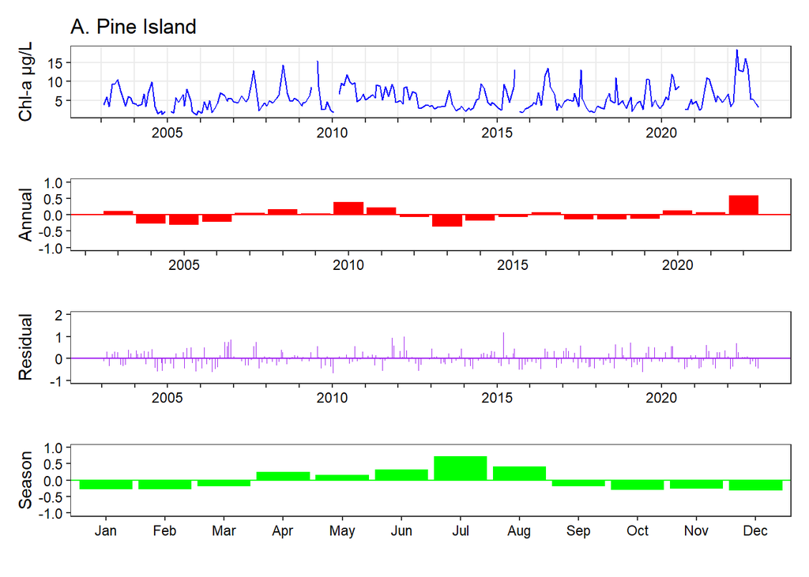

```r
a <- ggplot(decomp_pi) +
            geom_line(aes(x = date, y = value), color = "blue") +
            scale_x_date(date_breaks = "year", date_labels = "%Y") +
            theme_bw() +
            theme(axis.text.x = element_text(colour = c(NA, NA, "black", NA, NA)),
                  panel.grid.minor = element_blank(),
                  axis.text = element_text(color = "black")) +
            labs(x = '',
                 y = 'Chl-a \u00b5g/L',
                 title = "A. Pine Island")
    b <- decomp_pi %>%
          mutate(year = year(date)) %>%
          select(year, interann) %>%
          unique() %>%
          ggplot() +
            geom_col(aes(x = year, y = interann-1), fill = "red") +
            geom_hline(yintercept = 0, color = "red") +
            scale_x_continuous(breaks = seq(2000, 2022, by = 1)) +
            scale_y_continuous(limits = c(-1,1)) +
            theme_bw() +
            theme(axis.text.x = element_text(colour = c(NA, NA, NA, "black", NA)),
                  panel.grid = element_blank(),
                  axis.text = element_text(color = "black")) +
            labs(x = '',
                 y = 'Annual')
    c <- ggplot(decomp_pi) +
          geom_col(aes(x = date, y = events-1), fill = "purple") +
          geom_hline(yintercept = 0, color = "purple") +
          scale_x_date(date_breaks = "year", date_labels = "%Y") +
          scale_y_continuous(limits = c(-1,2)) +
          theme_bw() +
          theme(axis.text.x = element_text(colour = c(NA, NA,"black", NA, NA)),
                panel.grid = element_blank(),
                axis.text = element_text(color = "black")) +
          labs(x = '',
               y = 'Residual')
    d <- decomp_pi %>%
          mutate(month = month(date, label = T)) %>%
          select(month, season) %>%
          unique %>%
          ggplot() +
            geom_col(aes(x = month, y = season-1), fill = "green") +
            geom_hline(yintercept = 0, color = "green") +
            scale_y_continuous(limits = c(-1,1)) +
            theme_bw() +
            theme(axis.text = element_text(color = "black"),
                  panel.grid = element_blank()) +
            labs(x = '',
                 y = 'Season')
a/b/c/d
```

### San Sebastian

Using the decomposition function from (**cloern2010?**), summary information

```r
summary(decomp.mult(ts(as.data.frame(chla_dat %>%
                                       filter(station == "gtmssnut") %>%
                                       select(date, value) %>%
                                       bind_rows(mis) %>%
                                       arrange(date) %>%
                                       select(value)
                                     ),
                        start = c(2003, 1),
                        end = c(2022, 12),
                        frequency = 12)))
```

```
    original        grandmean        interann          season
 Min.   : 0.900   Min.   :4.521   Min.   :0.5449   Min.   :0.6712
 1st Qu.: 3.000   1st Qu.:4.521   1st Qu.:0.8917   1st Qu.:0.7760
 Median : 4.225   Median :4.521   Median :1.0040   Median :1.0548
 Mean   : 4.521   Mean   :4.521   Mean   :1.0017   Mean   :1.0013
 3rd Qu.: 5.638   3rd Qu.:4.521   3rd Qu.:1.1333   3rd Qu.:1.1853
 Max.   :14.050   Max.   :4.521   Max.   :1.4428   Max.   :1.3358
 NA's   :6
     events
 Min.   :0.3944
 1st Qu.:0.7897
 Median :0.9303
 Mean   :1.0000
 3rd Qu.:1.1626
 Max.   :2.7343
 NA's   :6
```

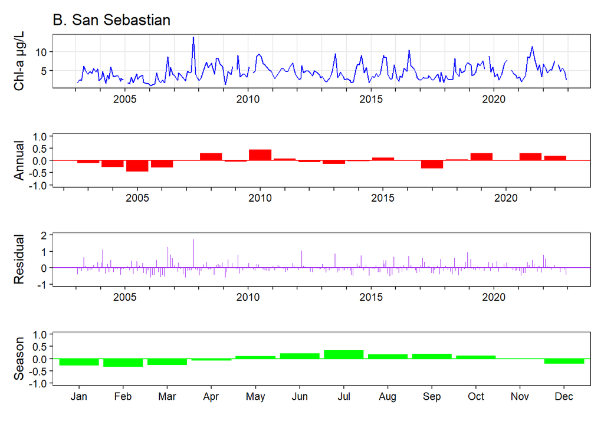

```r
a <- ggplot(decomp_ss) +
            geom_line(aes(x = date, y = value), color = "blue") +
            scale_x_date(date_breaks = "year", date_labels = "%Y") +
            theme_bw() +
            theme(axis.text.x = element_text(colour = c(NA, NA, "black", NA, NA)),
                  panel.grid.minor = element_blank(),
                  axis.text = element_text(color = "black")) +
            labs(x = '',
                 y = 'Chl-a \u00b5g/L',
                 title = "B. San Sebastian")
    b <- decomp_ss %>%
          mutate(year = year(date)) %>%
          select(year, interann) %>%
          unique() %>%
          ggplot() +
            geom_col(aes(x = year, y = interann-1), fill = "red") +
            geom_hline(yintercept = 0, color = "red") +
            scale_x_continuous(breaks = seq(2000, 2022, by = 1)) +
            scale_y_continuous(limits = c(-1,1)) +
            theme_bw() +
            theme(axis.text.x = element_text(colour = c(NA, NA, NA, "black", NA)),
                  panel.grid = element_blank(),
                  axis.text = element_text(color = "black")) +
            labs(x = '',
                 y = 'Annual')
    c <- ggplot(decomp_ss) +
          geom_col(aes(x = date, y = events-1), fill = "purple") +
          geom_hline(yintercept = 0, color = "purple") +
          scale_x_date(date_breaks = "year", date_labels = "%Y") +
          scale_y_continuous(limits = c(-1,2)) +
          theme_bw() +
          theme(axis.text.x = element_text(colour = c(NA, NA,"black", NA, NA)),
                panel.grid = element_blank(),
                axis.text = element_text(color = "black")) +
          labs(x = '',
               y = 'Residual')
    d <- decomp_ss %>%
          mutate(month = month(date, label = T)) %>%
          select(month, season) %>%
          unique %>%
          ggplot() +
            geom_col(aes(x = month, y = season-1), fill = "green") +
            geom_hline(yintercept = 0, color = "green") +
            scale_y_continuous(limits = c(-1,1)) +
            theme_bw() +
            theme(axis.text = element_text(color = "black"),
                  panel.grid = element_blank()) +
            labs(x = '',
                 y = 'Season')
a/b/c/d
```

### Fort Matanzas

Using the decomposition function from (**cloern2010?**), summary information

```r
summary(decomp.mult(ts(as.data.frame(chla_dat %>%
                                       filter(station == "gtmfmnut") %>%
                                       select(date, value) %>%
                                       bind_rows(mis) %>%
                                       arrange(date) %>%
                                       select(value)
                                     ),
                        start = c(2003, 1),
                        end = c(2022, 12),
                        frequency = 12)))
```

```
    original        grandmean        interann          season
 Min.   : 0.550   Min.   :3.827   Min.   :0.6011   Min.   :0.5115
 1st Qu.: 2.250   1st Qu.:3.827   1st Qu.:0.7927   1st Qu.:0.6263
 Median : 3.475   Median :3.827   Median :1.0148   Median :1.0626
 Mean   : 3.827   Mean   :3.827   Mean   :1.0004   Mean   :0.9976
 3rd Qu.: 4.763   3rd Qu.:3.827   3rd Qu.:1.2051   3rd Qu.:1.2808
 Max.   :23.450   Max.   :3.827   Max.   :1.4754   Max.   :1.4501
 NA's   :4
     events
 Min.   :0.3498
 1st Qu.:0.7375
 Median :0.9360
 Mean   :1.0000
 3rd Qu.:1.1550
 Max.   :3.4044
 NA's   :4
```

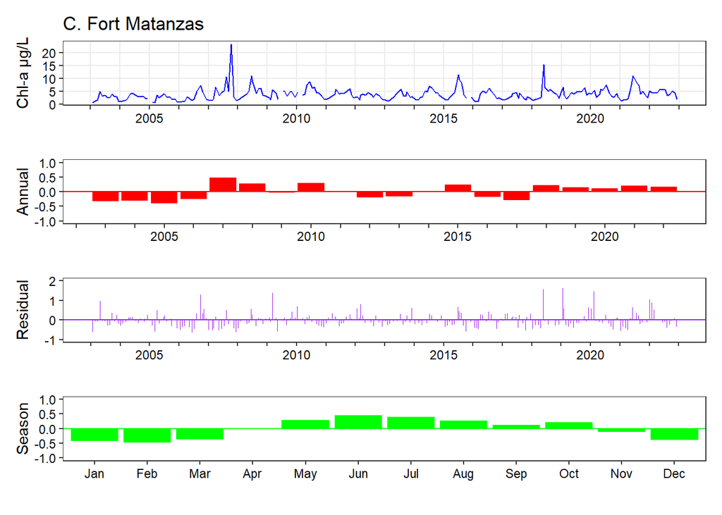

```r
a <- ggplot(decomp_fm) +
            geom_line(aes(x = date, y = value), color = "blue") +
            scale_x_date(date_breaks = "year", date_labels = "%Y") +
            theme_bw() +
            theme(axis.text.x = element_text(colour = c(NA, NA, "black", NA, NA)),
                  panel.grid.minor = element_blank(),
                  axis.text = element_text(color = "black")) +
            labs(x = '',
                 y = 'Chl-a \u00b5g/L',
                 title = "C. Fort Matanzas")
    b <- decomp_fm %>%
          mutate(year = year(date)) %>%
          select(year, interann) %>%
          unique() %>%
          ggplot() +
            geom_col(aes(x = year, y = interann-1), fill = "red") +
            geom_hline(yintercept = 0, color = "red") +
            scale_x_continuous(breaks = seq(2000, 2022, by = 1)) +
            scale_y_continuous(limits = c(-1,1)) +
            theme_bw() +
            theme(axis.text.x = element_text(colour = c(NA, NA, NA, "black", NA)),
                  panel.grid = element_blank(),
                  axis.text = element_text(color = "black")) +
            labs(x = '',
                 y = 'Annual')
    c <- ggplot(decomp_fm) +
          geom_col(aes(x = date, y = events-1), fill = "purple") +
          geom_hline(yintercept = 0, color = "purple") +
          scale_x_date(date_breaks = "year", date_labels = "%Y") +
          scale_y_continuous(limits = c(-1,2)) +
          theme_bw() +
          theme(axis.text.x = element_text(colour = c(NA, NA,"black", NA, NA)),
                panel.grid = element_blank(),
                axis.text = element_text(color = "black")) +
          labs(x = '',
               y = 'Residual')
    d <- decomp_fm %>%
          mutate(month = month(date, label = T)) %>%
          select(month, season) %>%
          unique %>%
          ggplot() +
            geom_col(aes(x = month, y = season-1), fill = "green") +
            geom_hline(yintercept = 0, color = "green") +
            scale_y_continuous(limits = c(-1,1)) +
            theme_bw() +
            theme(axis.text = element_text(color = "black"),
                  panel.grid = element_blank()) +
            labs(x = '',
                 y = 'Season')
a/b/c/d
```

### Pellicer Creek

Using the decomposition function from (**cloern2010?**), summary information

```r
summary(decomp.mult(ts(as.data.frame(chla_dat %>%
                                       filter(station == "gtmpcnut") %>%
                                       select(date, value) %>%
                                       bind_rows(mis) %>%
                                       arrange(date) %>%
                                       select(value)
                                     ),
                        start = c(2003, 1),
                        end = c(2022, 12),
                        frequency = 12)))
```

```
    original        grandmean        interann          season
 Min.   : 0.550   Min.   :8.602   Min.   :0.4066   Min.   :0.4959
 1st Qu.: 3.600   1st Qu.:8.602   1st Qu.:0.7393   1st Qu.:0.6630
 Median : 6.875   Median :8.602   Median :1.0102   Median :0.9309
 Mean   : 8.602   Mean   :8.602   Mean   :0.9994   Mean   :1.0029
 3rd Qu.:11.738   3rd Qu.:8.602   3rd Qu.:1.2055   3rd Qu.:1.2757
 Max.   :38.200   Max.   :8.602   Max.   :1.8926   Max.   :1.7377
 NA's   :8
     events
 Min.   :0.08924
 1st Qu.:0.66536
 Median :0.96278
 Mean   :1.00000
 3rd Qu.:1.28492
 Max.   :2.97525
 NA's   :8
```

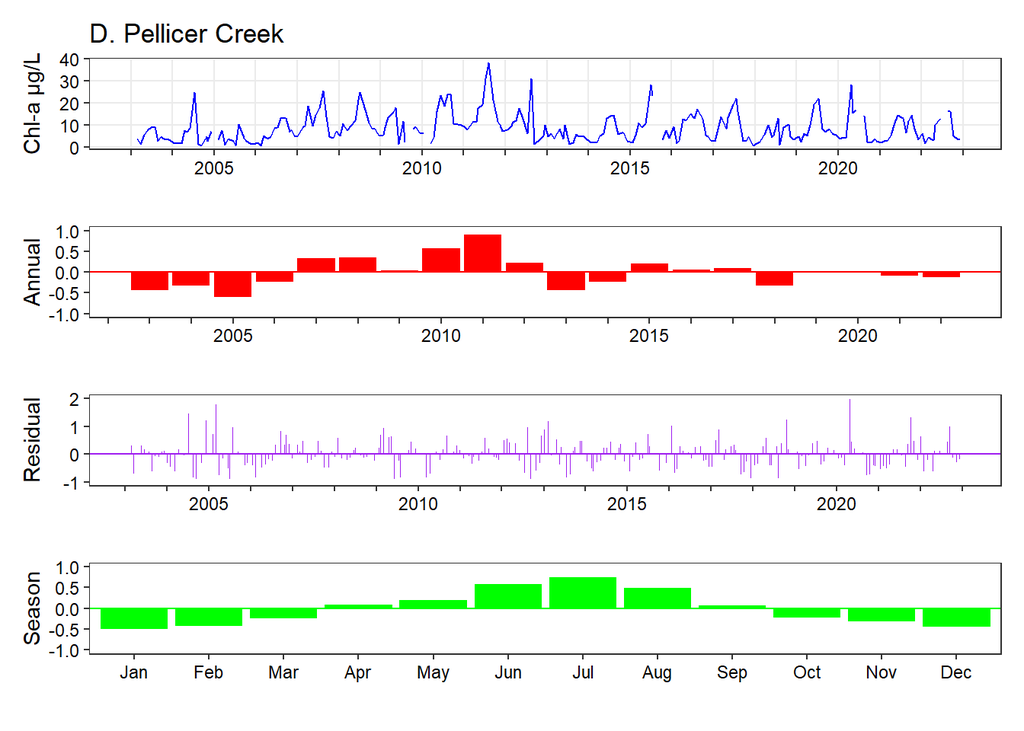

```r
a <- ggplot(decomp_pc) +
            geom_line(aes(x = date, y = value), color = "blue") +
            scale_x_date(date_breaks = "year", date_labels = "%Y") +
            theme_bw() +
            theme(axis.text.x = element_text(colour = c(NA, NA, "black", NA, NA)),
                  panel.grid.minor = element_blank(),
                  axis.text = element_text(color = "black")) +
            labs(x = '',
                 y = 'Chl-a \u00b5g/L',
                 title = "D. Pellicer Creek")
    b <- decomp_pc %>%
          mutate(year = year(date)) %>%
          select(year, interann) %>%
          unique() %>%
          ggplot() +
            geom_col(aes(x = year, y = interann-1), fill = "red") +
            geom_hline(yintercept = 0, color = "red") +
            scale_x_continuous(breaks = seq(2000, 2022, by = 1)) +
            scale_y_continuous(limits = c(-1,1)) +
            theme_bw() +
            theme(axis.text.x = element_text(colour = c(NA, NA, NA, "black", NA)),
                  panel.grid = element_blank(),
                  axis.text = element_text(color = "black")) +
            labs(x = '',
                 y = 'Annual')
    c <- ggplot(decomp_pc) +
          geom_col(aes(x = date, y = events-1), fill = "purple") +
          geom_hline(yintercept = 0, color = "purple") +
          scale_x_date(date_breaks = "year", date_labels = "%Y") +
          scale_y_continuous(limits = c(-1,2)) +
          theme_bw() +
          theme(axis.text.x = element_text(colour = c(NA, NA,"black", NA, NA)),
                panel.grid = element_blank(),
                axis.text = element_text(color = "black")) +
          labs(x = '',
               y = 'Residual')
    d <- decomp_pc %>%
          mutate(month = month(date, label = T)) %>%
          select(month, season) %>%
          unique %>%
          ggplot() +
            geom_col(aes(x = month, y = season-1), fill = "green") +
            geom_hline(yintercept = 0, color = "green") +
            scale_y_continuous(limits = c(-1,1)) +
            theme_bw() +
            theme(axis.text = element_text(color = "black"),
                  panel.grid = element_blank()) +
            labs(x = '',
                 y = 'Season')
a/b/c/d
```

## References

Beck, Marcus W., Perry De Valpine, Rebecca Murphy, Ian Wren, Ariella Chelsky, Melissa Foley, and David B. Senn. 2022. “Multi-Scale Trend Analysis of Water Quality Using Error Propagation of Generalized Additive Models.” *Science of The Total Environment* 802 (January): 149927. https://doi.org/10.1016/j.scitotenv.2021.149927.